# PEC 5 - Reglas de Asociación

Fernando Antonio Barbeiro Campos - fbarbeiro@uoc.edu

6 de May, 2018

# Presentación

Esta práctica cubre los Módulos 6 y 8 (Evaluación de modelos) del programa de la asignatura.

# Competencias

Las competencias que se trabajan en esta prueba son:

- Uso y aplicación de las TIC en el ámbito académico y profesional.
- Capacidad para innovar y generar nuevas ideas.
- Capacidad para evaluar soluciones tecnológicas y elaborar propuestas de proyectos teniendo en cuenta los recursos, las alternativas disponibles y las condiciones de mercado.
- Conocer las tecnologías de comunicaciones actuales y emergentes, así como saberlas aplicar convenientemente para diseñar y desarrollar soluciones basadas en sistemas y tecnologías de la información.
- Aplicación de las técnicas específicas de ingeniería del software en las diferentes etapas del ciclo de vida de un proyecto.
- Capacidad para aplicar las técnicas específicas de tratamiento, almacenamiento y administración de datos.
- Capacidad para proponer y evaluar diferentes alternativas tecnológicas para resolver un problema concreto.

# Objetivos

La correcta asimilación del Módulo 6 y el resto de Módulos trabajados: En esta PEC trabajaremos la generación e interpretación de un modelo de basado en reglas de asociación con los recursos de prácticas.

# Enunciado

Contextualizad los ejemplos de las siguientes preguntas respecto al proyecto que has definido en la PEC1. Si lo deseáis, podéis redefinir o afinar el proyecto.

1. ¿creéis que las reglas de asociación podrían ser el método finalmente escogido? ¿Os podrían aportar alguna cosa?
   - ¿Cómo podría ser el modelo resultante?
   - Dar un ejemplo de la interpretación que se podría derivar del modelo generado

## Respuesta

[output not shown]

```r
#my_file <- "lastfm.csv"
#cat("\n", file = my_file, append = TRUE)
#tdata <- read.transactions(file = my_file, rm.duplicates = FALSE, skip = 1, sep = ",")
#head(tdata)
#class(tdata)
#inspect(head(tdata))
#size(head(tdata))

#frequentItems <- eclat (tdata, parameter = list(supp = 0.07, maxlen = 15))
#inspect(frequentItems)
#itemFrequencyPlot(tdata, topN=15, type="absolute", main="Item Frequency")

#rules <- apriori (tdata, parameter = list(supp = 0.001, conf = 0.5))
#rules_conf <- sort (rules, by="confidence", decreasing=TRUE)
#inspect(head(rules_conf))
#rules_lift <- sort (rules, by="lift", decreasing=TRUE)
#inspect(head(rules_lift))
```

```r
library(knitr)

lastfm <- read.csv(file = "lastfm.csv")
head(lastfm)
```

```
##   user                  artist sex country
## 1    1   red hot chili peppers   f Germany
## 2    1 the black dahlia murder   f Germany
## 3    1               goldfrapp   f Germany
## 4    1        dropkick murphys   f Germany
## 5    1                le tigre   f Germany
## 6    1              schandmaul   f Germany
```

```r
summary(lastfm)
```

```
##       user                         artist       sex
##  Min.   :    1   radiohead            :  2704   f: 78132
##  1st Qu.: 4935   the beatles          :  2668   m:211823
##  Median : 9838   coldplay             :  2378
##  Mean   : 9852   red hot chili peppers:  1786
##  3rd Qu.:14769   muse                 :  1711
##  Max.   :19718   metallica            :  1670
##                  (Other)              :277038
##            country
##  United States : 59558
##  United Kingdom: 27638
##  Germany       : 24251
##  Poland        : 17111
##  Sweden        : 12379
##  Brazil        : 11922
##  (Other)       :137096
```

```r
nrow(lastfm)
```

```
## [1] 289955
```

```r
ncol(lastfm)
```

```
## [1] 4
```

```r
str(lastfm)
```

```
## 'data.frame':    289955 obs. of  4 variables:
##  $ user   : int  1 1 1 1 1 1 1 1 1 1 ...
##  $ artist : Factor w/ 1004 levels "...and you will know us by the trail of dead",..: 715 851 374 281 513 751 289 430 300 896 ...
##  $ sex    : Factor w/ 2 levels "f","m": 1 1 1 1 1 1 1 1 1 1 ...
##  $ country: Factor w/ 159 levels "Afghanistan",..: 58 58 58 58 58 58 58 58 58 58 ...
```

```r
res <- sapply(lastfm, class)
kable(data.frame(variables=names(res),clase=as.vector(res)))
```

| variables | clase |
| --- | --- |
| user | integer |
| artist | factor |
| sex | factor |
| country | factor |

```r
unlist(lapply(lastfm, function(x) any(is.na(x))))
```

```
##    user  artist     sex country
##   FALSE   FALSE   FALSE   FALSE
```

```r
#Distribucion de valores
head(table(lastfm$artist))
```

```
##
## ...and you will know us by the trail of dead
##                                          147
##                                    [unknown]
##                                          553
##                                         2pac
##                                          341
##                                 3 doors down
##                                          464
##                           30 seconds to mars
##                                          492
##                                          311
##                                          125
```

```r
head(table(lastfm$user))
```

```
##
##  1  3  4  5  6  7
## 16 29 27 11 23 22
```

```r
dist_sex <- table(lastfm$sex)
head(table(lastfm$country))
```

```
##
##    Afghanistan        Albania        Algeria American Samoa        Andorra
##             51             49             42             16             33
##         Angola
##             38
```

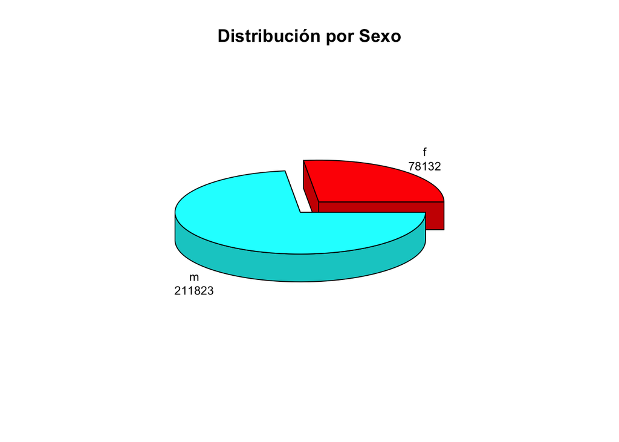

```r
library (plotrix)

lbls <- paste(names(dist_sex),  "\n" , dist_sex, sep= "" )
pie3D(dist_sex
       , radius= 0.9
       , labelcex=  0.8
       , labels = lbls
       , explode= 0.1
       , main= "Distribución por Sexo" , col = rainbow(length(lbls)
       ))
```

```r
qtt_users <- aggregate(data.frame(count = lastfm$user),
               by = list(value = lastfm$user),
               FUN = length)
#Numero de usuarios
nrow(qtt_users)
```

```
## [1] 15000
```

```r
head(qtt_users[order(qtt_users$count,  decreasing = TRUE), ])
```

```
##       value count
## 13460 17681    76
## 11495 15057    63
## 929    1208    55
## 14873 19558    55
## 10232 13424    54
## 2486   3288    52
```

```r
qtt_artists <- aggregate(data.frame(count = lastfm$artist), list(value = lastfm$artist), length)
#¿Cuantos grupos musicales hay?
nrow(qtt_artists)
```

```
## [1] 1004
```

```r
head(qtt_artists[order(qtt_artists$count,  decreasing = TRUE), ])
```

```
##                     value count
## 705             radiohead  2704
## 849           the beatles  2668
## 204              coldplay  2378
## 715 red hot chili peppers  1786
## 606                  muse  1711
## 568             metallica  1670
```

```r
#colnames(lastfm)
#drops <- c("sex","country")
#lastfm <- lastfm[ , !(names(lastfm) %in% drops)]
#class(lastfm)
#str(lastfm)

#nrow(lastfm)

#my_duplicated_list <- lastfm[duplicated(lastfm),]
#my_duplicated_list
#nrow(my_duplicated_list)

#not_duplicated <- lastfm[!duplicated(lastfm), ]
#nrow(not_duplicated)

#otra aproximacao
#unicos <- unique(lastfm)
#nrow(unicos)

#Binarizando
#t_lastfm <- as (not_duplicated, "transactions")
#head(t_lastfm)
```

```r
lastfm <- read.csv(file = "lastfm.csv")
mba <- split (x = lastfm [, "artist"], f = lastfm$user)
mba <- lapply (mba, unique)
mba <- as (mba, "transactions")
class(mba)
```

```
## [1] "transactions"
## attr(,"package")
## [1] "arules"
```

```r
head(mba)
```

```
## transactions in sparse format with
##  6 transactions (rows) and
##  1004 items (columns)
```

```r
apriori(mba)
```

```
## Apriori
##
## Parameter specification:
##  confidence minval smax arem  aval originalSupport maxtime support minlen
##         0.8    0.1    1 none FALSE            TRUE       5     0.1      1
##  maxlen target   ext
##      10  rules FALSE
##
## Algorithmic control:
##  filter tree heap memopt load sort verbose
##     0.1 TRUE TRUE  FALSE TRUE    2    TRUE
##
## Absolute minimum support count: 1500
##
## set item appearances ...[0 item(s)] done [0.00s].
## set transactions ...[1004 item(s), 15000 transaction(s)] done [0.02s].
## sorting and recoding items ... [7 item(s)] done [0.00s].
## creating transaction tree ... done [0.00s].
## checking subsets of size 1 2 done [0.00s].
## writing ... [0 rule(s)] done [0.00s].
## creating S4 object  ... done [0.00s].
```

```
## set of 0 rules
```

```r
apriori(mba, parameter=list(support=0.01, confidence=0.5))
```

```
## Apriori
##
## Parameter specification:
##  confidence minval smax arem  aval originalSupport maxtime support minlen
##         0.5    0.1    1 none FALSE            TRUE       5    0.01      1
##  maxlen target   ext
##      10  rules FALSE
##
## Algorithmic control:
##  filter tree heap memopt load sort verbose
##     0.1 TRUE TRUE  FALSE TRUE    2    TRUE
##
## Absolute minimum support count: 150
##
## set item appearances ...[0 item(s)] done [0.00s].
## set transactions ...[1004 item(s), 15000 transaction(s)] done [0.02s].
## sorting and recoding items ... [655 item(s)] done [0.00s].
## creating transaction tree ... done [0.00s].
## checking subsets of size 1 2 3 4 done [0.02s].
## writing ... [50 rule(s)] done [0.00s].
## creating S4 object  ... done [0.00s].
```

```
## set of 50 rules
```

```r
my_file <- "lastfm.csv"
#Habia un warning de end of line, por esto el cat
cat("\n", file = my_file, append = TRUE)
tdata <- read.transactions(file = my_file, rm.duplicates = TRUE, skip = 1, sep = ",")
head(tdata)
```

```
## transactions in sparse format with
##  6 transactions (rows) and
##  16163 items (columns)
```

```r
class(tdata)
```

```
## [1] "transactions"
## attr(,"package")
## [1] "arules"
```

```r
inspect(head(tdata))
```

```
##     items
## [1] {1,f,Germany,red hot chili peppers}
## [2] {1,f,Germany,the black dahlia murder}
## [3] {1,f,Germany,goldfrapp}
## [4] {1,dropkick murphys,f,Germany}
## [5] {1,f,Germany,le tigre}
## [6] {1,f,Germany,schandmaul}
```

```r
apriori(mba)
```

```
## Apriori
##
## Parameter specification:
##  confidence minval smax arem  aval originalSupport maxtime support minlen
##         0.8    0.1    1 none FALSE            TRUE       5     0.1      1
##  maxlen target   ext
##      10  rules FALSE
##
## Algorithmic control:
##  filter tree heap memopt load sort verbose
##     0.1 TRUE TRUE  FALSE TRUE    2    TRUE
##
## Absolute minimum support count: 1500
##
## set item appearances ...[0 item(s)] done [0.00s].
## set transactions ...[1004 item(s), 15000 transaction(s)] done [0.02s].
## sorting and recoding items ... [7 item(s)] done [0.00s].
## creating transaction tree ... done [0.00s].
## checking subsets of size 1 2 done [0.00s].
## writing ... [0 rule(s)] done [0.00s].
## creating S4 object  ... done [0.00s].
```

```
## set of 0 rules
```

```r
apriori(mba, parameter=list(support=0.01, confidence=0.5))
```

```
## Apriori
##
## Parameter specification:
##  confidence minval smax arem  aval originalSupport maxtime support minlen
##         0.5    0.1    1 none FALSE            TRUE       5    0.01      1
##  maxlen target   ext
##      10  rules FALSE
##
## Algorithmic control:
##  filter tree heap memopt load sort verbose
##     0.1 TRUE TRUE  FALSE TRUE    2    TRUE
##
## Absolute minimum support count: 150
##
## set item appearances ...[0 item(s)] done [0.00s].
## set transactions ...[1004 item(s), 15000 transaction(s)] done [0.02s].
## sorting and recoding items ... [655 item(s)] done [0.00s].
## creating transaction tree ... done [0.00s].
## checking subsets of size 1 2 3 4 done [0.02s].
## writing ... [50 rule(s)] done [0.00s].
## creating S4 object  ... done [0.00s].
```

```
## set of 50 rules
```

```r
apriori(tdata)
```

```
## Apriori
##
## Parameter specification:
##  confidence minval smax arem  aval originalSupport maxtime support minlen
##         0.8    0.1    1 none FALSE            TRUE       5     0.1      1
##  maxlen target   ext
##      10  rules FALSE
##
## Algorithmic control:
##  filter tree heap memopt load sort verbose
##     0.1 TRUE TRUE  FALSE TRUE    2    TRUE
##
## Absolute minimum support count: 28996
##
## set item appearances ...[0 item(s)] done [0.00s].
## set transactions ...[16163 item(s), 289966 transaction(s)] done [0.08s].
## sorting and recoding items ... [3 item(s)] done [0.00s].
## creating transaction tree ... done [0.04s].
## checking subsets of size 1 2 done [0.00s].
## writing ... [0 rule(s)] done [0.00s].
## creating S4 object  ... done [0.03s].
```

```
## set of 0 rules
```

```r
apriori(tdata, parameter=list(support=0.01, confidence=0.5))
```

```
## Apriori
##
## Parameter specification:
##  confidence minval smax arem  aval originalSupport maxtime support minlen
##         0.5    0.1    1 none FALSE            TRUE       5    0.01      1
##  maxlen target   ext
##      10  rules FALSE
##
## Algorithmic control:
##  filter tree heap memopt load sort verbose
##     0.1 TRUE TRUE  FALSE TRUE    2    TRUE
##
## Absolute minimum support count: 2899
##
## set item appearances ...[0 item(s)] done [0.00s].
## set transactions ...[16163 item(s), 289966 transaction(s)] done [0.08s].
## sorting and recoding items ... [21 item(s)] done [0.00s].
## creating transaction tree ... done [0.06s].
## checking subsets of size 1 2 done [0.00s].
## writing ... [19 rule(s)] done [0.00s].
## creating S4 object  ... done [0.03s].
```

```
## set of 19 rules
```

```r
summary(mba)
```

```
## transactions as itemMatrix in sparse format with
##  15000 rows (elements/itemsets/transactions) and
##  1004 columns (items) and a density of 0.01925319
##
## most frequent items:
##             radiohead           the beatles              coldplay
##                  2704                  2668                  2378
## red hot chili peppers                  muse               (Other)
##                  1786                  1711                278706
##
## element (itemset/transaction) length distribution:
## sizes
##   1   2   3   4   5   6   7   8   9  10  11  12  13  14  15  16  17  18
## 185 222 280 302 359 385 472 461 491 501 504 482 472 471 479 477 456 455
##  19  20  21  22  23  24  25  26  27  28  29  30  31  32  33  34  35  36
## 444 455 436 478 426 438 408 446 417 375 348 340 316 293 274 286 238 208
##  37  38  39  40  41  42  43  44  45  46  47  48  49  50  51  52  54  55
## 193 181 128 102  93  61  55  36  23  15   6  11   2   1   5   3   1   2
##  63  76
##   1   1
##
##    Min. 1st Qu.  Median    Mean 3rd Qu.    Max.
##    1.00   11.00   19.00   19.33   27.00   76.00
##
## includes extended item information - examples:
##                                         labels
## 1 ...and you will know us by the trail of dead
## 2                                    [unknown]
## 3                                         2pac
##
## includes extended transaction information - examples:
##   transactionID
## 1             1
## 2             3
## 3             4
```

```r
summary(tdata)
```

```
## transactions as itemMatrix in sparse format with
##  289966 rows (elements/itemsets/transactions) and
##  16163 columns (items) and a density of 0.0002474694
##
## most frequent items:
##              m              f  United States United Kingdom        Germany
##         211823          78132          59558          27638          24251
##        (Other)
##         758418
##
## element (itemset/transaction) length distribution:
## sizes
##      0      4
##     11 289955
##
##    Min. 1st Qu.  Median    Mean 3rd Qu.    Max.
##       0       4       4       4       4       4
##
## includes extended item information - examples:
##                                         labels
## 1 ...and you will know us by the trail of dead
## 2                                    [unknown]
## 3                                            1
```

```r
frequent_items_tdata <- eclat (tdata, parameter = list(supp = 0.07, maxlen = 15))
```

```
## Eclat
##
## parameter specification:
##  tidLists support minlen maxlen            target   ext
##     FALSE    0.07      1     15 frequent itemsets FALSE
##
## algorithmic control:
##  sparse sort verbose
##       7   -2    TRUE
##
## Absolute minimum support count: 20297
##
## create itemset ...
## set transactions ...[16163 item(s), 289966 transaction(s)] done [0.08s].
## sorting and recoding items ... [5 item(s)] done [0.00s].
## creating bit matrix ... [5 row(s), 289966 column(s)] done [0.02s].
## writing  ... [7 set(s)] done [0.00s].
## Creating S4 object  ... done [0.00s].
```

```r
inspect(frequent_items_tdata)
```

```
##     items              support    count
## [1] {m,United Kingdom} 0.07730217  22415
## [2] {m,United States}  0.13852314  40167
## [3] {m}                0.73050978 211823
## [4] {f}                0.26945228  78132
## [5] {United States}    0.20539649  59558
## [6] {United Kingdom}   0.09531462  27638
## [7] {Germany}          0.08363394  24251
```

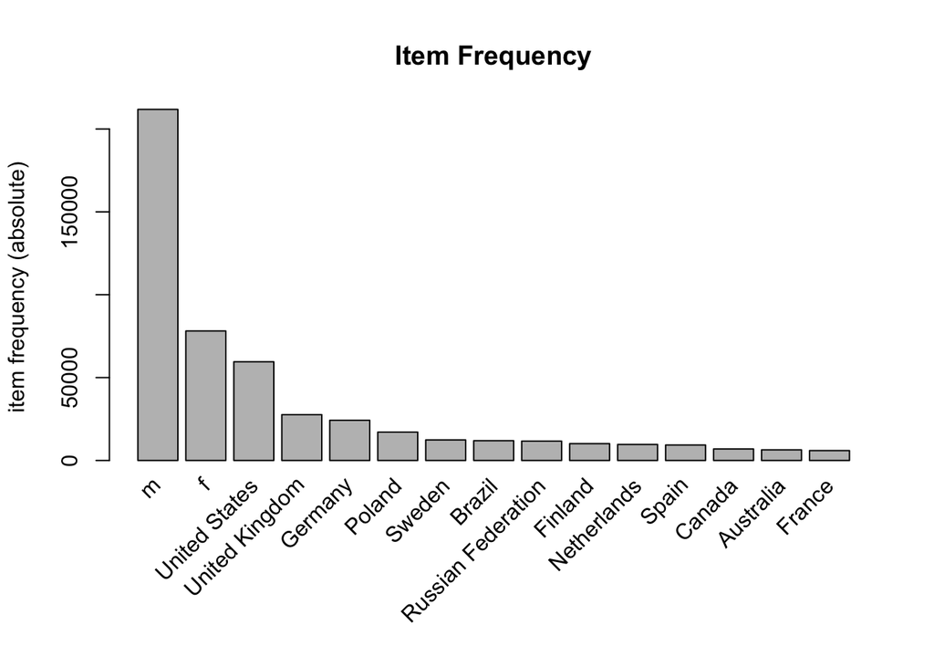

```r
itemFrequencyPlot(tdata, topN=15, type="absolute", main="Item Frequency")
```

```r
frequent_items_mba <- eclat (mba, parameter = list(supp = 0.07, maxlen = 15))
```

```
## Eclat
##
## parameter specification:
##  tidLists support minlen maxlen            target   ext
##     FALSE    0.07      1     15 frequent itemsets FALSE
##
## algorithmic control:
##  sparse sort verbose
##       7   -2    TRUE
##
## Absolute minimum support count: 1050
##
## create itemset ...
## set transactions ...[1004 item(s), 15000 transaction(s)] done [0.02s].
## sorting and recoding items ... [23 item(s)] done [0.00s].
## creating sparse bit matrix ... [23 row(s), 15000 column(s)] done [0.00s].
## writing  ... [23 set(s)] done [0.00s].
## Creating S4 object  ... done [0.00s].
```

```r
inspect(frequent_items_mba)
```

```
##      items                   support    count
## [1]  {radiohead}             0.18026667 2704
## [2]  {the beatles}           0.17786667 2668
## [3]  {coldplay}              0.15853333 2378
## [4]  {red hot chili peppers} 0.11906667 1786
## [5]  {muse}                  0.11406667 1711
## [6]  {metallica}             0.11133333 1670
## [7]  {the killers}           0.09820000 1473
## [8]  {pink floyd}            0.10493333 1574
## [9]  {nirvana}               0.09820000 1473
## [10] {linkin park}           0.09820000 1473
## [11] {system of a down}      0.09100000 1365
## [12] {death cab for cutie}   0.08133333 1220
## [13] {arctic monkeys}        0.07546667 1132
## [14] {foo fighters}          0.07333333 1100
## [15] {led zeppelin}          0.07920000 1188
## [16] {placebo}               0.07746667 1162
## [17] {the cure}              0.07593333 1139
## [18] {daft punk}             0.07600000 1140
## [19] {david bowie}           0.07366667 1105
## [20] {queen}                 0.07773333 1166
## [21] {green day}             0.07086667 1063
## [22] {depeche mode}          0.07546667 1132
## [23] {rammstein}             0.07006667 1051
```

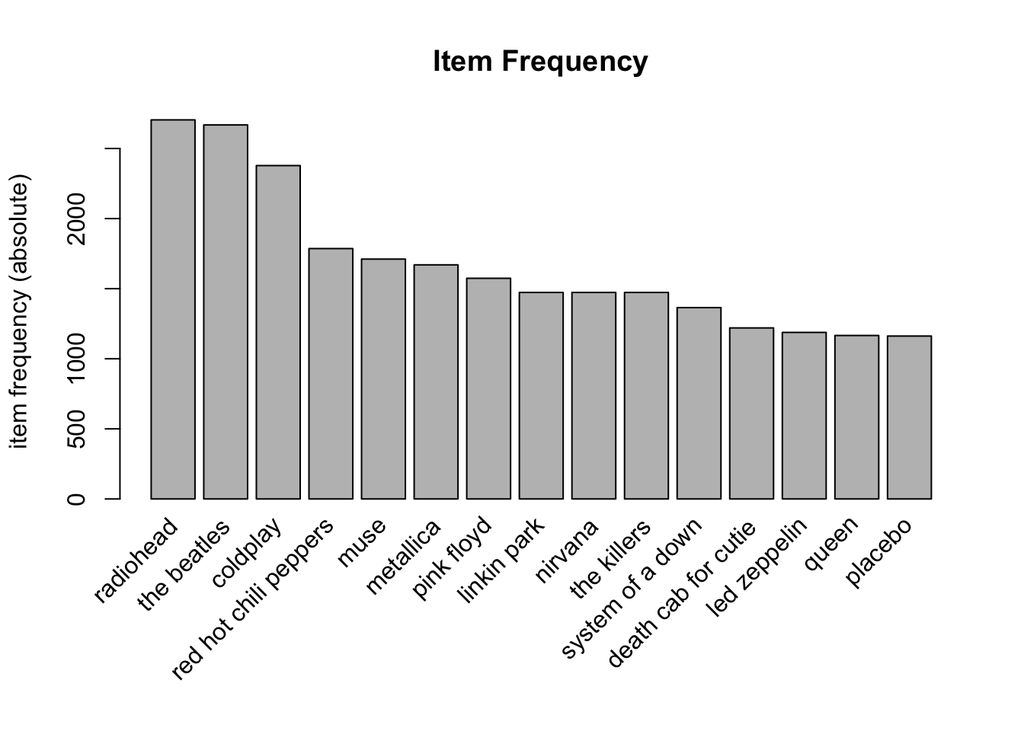

```r
itemFrequencyPlot(mba, topN=15, type="absolute", main="Item Frequency")
```

```r
rules_mba <- apriori(mba, parameter=list(support=0.015, confidence=0.5, ext=TRUE))
```

```
## Apriori
##
## Parameter specification:
##  confidence minval smax arem  aval originalSupport maxtime support minlen
##         0.5    0.1    1 none FALSE            TRUE       5   0.015      1
##  maxlen target  ext
##      10  rules TRUE
##
## Algorithmic control:
##  filter tree heap memopt load sort verbose
##     0.1 TRUE TRUE  FALSE TRUE    2    TRUE
##
## Absolute minimum support count: 225
##
## set item appearances ...[0 item(s)] done [0.00s].
## set transactions ...[1004 item(s), 15000 transaction(s)] done [0.02s].
## sorting and recoding items ... [417 item(s)] done [0.00s].
## creating transaction tree ... done [0.00s].
## checking subsets of size 1 2 3 done [0.01s].
## writing ... [9 rule(s)] done [0.00s].
## creating S4 object  ... done [0.00s].
```

```r
rules_tdata <- apriori(tdata, parameter=list(support=0.015, confidence=0.5))
```

```
## Apriori
##
## Parameter specification:
##  confidence minval smax arem  aval originalSupport maxtime support minlen
##         0.5    0.1    1 none FALSE            TRUE       5   0.015      1
##  maxlen target   ext
##      10  rules FALSE
##
## Algorithmic control:
##  filter tree heap memopt load sort verbose
##     0.1 TRUE TRUE  FALSE TRUE    2    TRUE
##
## Absolute minimum support count: 4349
##
## set item appearances ...[0 item(s)] done [0.00s].
## set transactions ...[16163 item(s), 289966 transaction(s)] done [0.08s].
## sorting and recoding items ... [18 item(s)] done [0.00s].
## creating transaction tree ... done [0.06s].
## checking subsets of size 1 2 done [0.00s].
## writing ... [14 rule(s)] done [0.00s].
## creating S4 object  ... done [0.03s].
```

```r
items(rules_mba)
```

```
## itemMatrix in sparse format with
##  9 rows (elements/transactions) and
##  1004 columns (items)
```

```r
items(rules_tdata)
```

```
## itemMatrix in sparse format with
##  14 rows (elements/transactions) and
##  16163 columns (items)
```

```r
inspect(rules_mba)
```

```
##     lhs                        rhs           support    confidence
## [1] {megadeth}              => {metallica}   0.01626667 0.5281385
## [2] {simon & garfunkel}     => {the beatles} 0.01540000 0.5238095
## [3] {broken social scene}   => {radiohead}   0.01506667 0.5472155
## [4] {blur}                  => {radiohead}   0.01753333 0.5228628
## [5] {keane}                 => {coldplay}    0.02226667 0.6374046
## [6] {snow patrol}           => {coldplay}    0.02646667 0.5251323
## [7] {beck}                  => {radiohead}   0.02926667 0.5092807
## [8] {muse,the killers}      => {coldplay}    0.01513333 0.5089686
## [9] {radiohead,the killers} => {coldplay}    0.01506667 0.5243619
##     lhs.support lift     count
## [1] 0.03080000  4.743759 244
## [2] 0.02940000  2.944956 231
## [3] 0.02753333  3.035589 226
## [4] 0.03353333  2.900496 263
## [5] 0.03493333  4.020634 334
## [6] 0.05040000  3.312441 397
## [7] 0.05746667  2.825152 439
## [8] 0.02973333  3.210483 227
## [9] 0.02873333  3.307582 226
```

```r
inspect(rules_tdata)
```

```
##      lhs                     rhs support    confidence lift      count
## [1]  {}                   => {m} 0.73050978 0.7305098  1.0000000 211823
## [2]  {Italy}              => {m} 0.01501555 0.7615882  1.0425435   4354
## [3]  {France}             => {m} 0.01707097 0.8302583  1.1365465   4950
## [4]  {Canada}             => {m} 0.01568115 0.6563222  0.8984441   4547
## [5]  {Spain}              => {m} 0.02482015 0.7720446  1.0568573   7197
## [6]  {Netherlands}        => {m} 0.02690315 0.8064716  1.1039847   7801
## [7]  {Finland}            => {m} 0.02661002 0.7596731  1.0399219   7716
## [8]  {Russian Federation} => {m} 0.03062428 0.7605344  1.0411009   8880
## [9]  {Brazil}             => {m} 0.03001731 0.7300788  0.9994101   8704
## [10] {Sweden}             => {m} 0.03193133 0.7479603  1.0238881   9259
## [11] {Poland}             => {m} 0.03854245 0.6531471  0.8940977  11176
## [12] {Germany}            => {m} 0.06069677 0.7257433  0.9934751  17600
## [13] {United Kingdom}     => {m} 0.07730217 0.8110211  1.1102125  22415
## [14] {United States}      => {m} 0.13852314 0.6744182  0.9232159  40167
```

```r
rules_conf <- sort (rules_mba, by="confidence", decreasing=TRUE)
inspect(rules_conf)
```

```
##     lhs                        rhs           support    confidence
## [1] {keane}                 => {coldplay}    0.02226667 0.6374046
## [2] {broken social scene}   => {radiohead}   0.01506667 0.5472155
## [3] {megadeth}              => {metallica}   0.01626667 0.5281385
## [4] {snow patrol}           => {coldplay}    0.02646667 0.5251323
## [5] {radiohead,the killers} => {coldplay}    0.01506667 0.5243619
## [6] {simon & garfunkel}     => {the beatles} 0.01540000 0.5238095
## [7] {blur}                  => {radiohead}   0.01753333 0.5228628
## [8] {beck}                  => {radiohead}   0.02926667 0.5092807
## [9] {muse,the killers}      => {coldplay}    0.01513333 0.5089686
##     lhs.support lift     count
## [1] 0.03493333  4.020634 334
## [2] 0.02753333  3.035589 226
## [3] 0.03080000  4.743759 244
## [4] 0.05040000  3.312441 397
## [5] 0.02873333  3.307582 226
## [6] 0.02940000  2.944956 231
## [7] 0.03353333  2.900496 263
## [8] 0.05746667  2.825152 439
## [9] 0.02973333  3.210483 227
```

```r
rules_lift <- sort (rules_mba, by="lift", decreasing=TRUE)
inspect(rules_lift)
```

```
##     lhs                        rhs           support    confidence
## [1] {megadeth}              => {metallica}   0.01626667 0.5281385
## [2] {keane}                 => {coldplay}    0.02226667 0.6374046
## [3] {snow patrol}           => {coldplay}    0.02646667 0.5251323
## [4] {radiohead,the killers} => {coldplay}    0.01506667 0.5243619
## [5] {muse,the killers}      => {coldplay}    0.01513333 0.5089686
## [6] {broken social scene}   => {radiohead}   0.01506667 0.5472155
## [7] {simon & garfunkel}     => {the beatles} 0.01540000 0.5238095
## [8] {blur}                  => {radiohead}   0.01753333 0.5228628
## [9] {beck}                  => {radiohead}   0.02926667 0.5092807
##     lhs.support lift     count
## [1] 0.03080000  4.743759 244
## [2] 0.03493333  4.020634 334
## [3] 0.05040000  3.312441 397
## [4] 0.02873333  3.307582 226
## [5] 0.02973333  3.210483 227
## [6] 0.02753333  3.035589 226
## [7] 0.02940000  2.944956 231
## [8] 0.03353333  2.900496 263
## [9] 0.05746667  2.825152 439
```

```r
inspect(rules_tdata)
```

```
##      lhs                     rhs support    confidence lift      count
## [1]  {}                   => {m} 0.73050978 0.7305098  1.0000000 211823
## [2]  {Italy}              => {m} 0.01501555 0.7615882  1.0425435   4354
## [3]  {France}             => {m} 0.01707097 0.8302583  1.1365465   4950
## [4]  {Canada}             => {m} 0.01568115 0.6563222  0.8984441   4547
## [5]  {Spain}              => {m} 0.02482015 0.7720446  1.0568573   7197
## [6]  {Netherlands}        => {m} 0.02690315 0.8064716  1.1039847   7801
## [7]  {Finland}            => {m} 0.02661002 0.7596731  1.0399219   7716
## [8]  {Russian Federation} => {m} 0.03062428 0.7605344  1.0411009   8880
## [9]  {Brazil}             => {m} 0.03001731 0.7300788  0.9994101   8704
## [10] {Sweden}             => {m} 0.03193133 0.7479603  1.0238881   9259
## [11] {Poland}             => {m} 0.03854245 0.6531471  0.8940977  11176
## [12] {Germany}            => {m} 0.06069677 0.7257433  0.9934751  17600
## [13] {United Kingdom}     => {m} 0.07730217 0.8110211  1.1102125  22415
## [14] {United States}      => {m} 0.13852314 0.6744182  0.9232159  40167
```